# Executive Function Engagement as a Slow–Fast Stochastic Dynamical System

Collaboration with prof. Yuko Munakata (UC-DAVIS)

Author

Affiliation

Kyuri Park

Computational Science Lab

Published

January 27, 2026

# Quick Intro

This document presents a stochastic differential equation (SDE) model of **executive function (EF) engagement**, based on the theory that children learn whether EF is *worth engaging* through experience.

> Core idea: children learn whether EF is worth engaging through experience, while EF capacity also grows gradually through maturation and practice.

The model separates:

- **Fast process (engagement):** moment-to-moment *propensity* to engage, $E(t)$
- **Slow processes (learning + development):** gradual learning of
  - expected value of EF $V(t)$
  - subjective cost of EF $C(t)$
  - EF capacity $K(t)$ (monotone developmental state)

[figure not shown]

The model is used to illustrate four qualitative behaviors:

1. Stable individual differences in engagement trajectories
2. Developmental improvements in capacity and typical engagement
3. Transient within-person fluctuations (e.g., stress)
4. Intervention timing effects (early vs. late reward changes)

# Model Overview

[output not shown]

## Fast Process: EF Engagement Propensity

At each moment $t$, the agent computes a **propensity** (interpretable as a probability or expected frequency) of engaging EF:

$$E(t) = \sigma\left(\frac{V(t) - \big(C(t) + \text{extra\_cost}(t)\big)}{\tau}\right),
\qquad \sigma(x) = \frac{1}{1+e^{-x}}.$$

Define the *instantaneous control utility*:
$$U(t)=V(t)-\big(C(t)+\text{extra\_cost}(t)\big),$$
so $E(t)=\sigma\big(U(t)/\tau\big)$.

Terms:

- $V(t)$: learned expected value of engaging EF
- $C(t)$: learned cost of engaging EF
- $\text{extra\_cost}(t)$: temporary situational load (e.g., stress) that raises immediate cost
- $\tau$: decision temperature; larger $\tau$ makes the logistic mapping flatter, so engagement is *less sensitive* to value–cost differences $V(t)-[C(t)+\text{extra\_cost}(t)]$
- $\sigma(\cdot)$: logistic function mapping utility to $[0,1]$

  > When $V(t)$ exceeds $C(t)+\text{extra\_cost}(t)$, utility is positive and $E(t)$ moves toward 1; when costs dominate, $E(t)$ moves toward 0.

## Slow Processes: Learning and Development (SDE Dynamics)

### $K$: Capacity dynamics (slow EF development)

We represent EF capacity explicitly, with a bounded development state $K(t)\in[0,1]$:

$$\frac{dK(t)}{dt}=\rho_{\text{mat}}\big(1-K(t)\big)+
\rho_{\text{prac}}E(t)\big(1-K(t)\big),
\qquad K(t)\in[0,1].$$

- $\rho_{\text{mat}}$: basline maturational growth
- $\rho_{\text{prac}}E(t)$: practice-driven growth (more engagement → faster capacity growth).
- $(1-K(t))$: saturation/headroom (growth slows as capacity approaches its ceiling).

**why (1−K)?**

$(1−K)$ is the remaining headroom—without it, capacity would grow linearly without bound; with it, growth naturally slows near a ceiling, which matches saturating developmental improvement.”

This gives a clean developmental interpretation:

- $K(t)$ is a *developmental* quantity $\rightarrow$ *slow, monotone, saturating*,
- $E(t)$ is an *engagement* quantity $\rightarrow$ *fast, fluctuating*,

### $V$: Value dynamics (learning “is EF worth it?”)

#### Expected reward signal (what value is learning toward)

When EF is engaged, it may yield reward. We summarize this with an *expected rewared rate*:

$$R^{\text{exp}}(t) \;=\; E(t)\cdot p_{\text{reward}}\cdot \text{reward\_mag}.$$

- $E(t)\in[0,1]$: the model’s *propensity* (probability / expected frequency) of engaging EF at time $t$
- $p_{\text{reward}}\in[0,1]$: probability of receiving reward **conditional on engaging EF** $P(reward|EF engaged)$ –> captures *how rewarding the environment is* when EF is engaged (environmental payoff rate; can vary with context or interventions)
- $\text{reward\_mag}$: reward magnitude (and therefore the scale of $V$)

**Why this is considered mean-field**

In a fully discrete version, two random events happen at each step:

1. engagement $A(t)\sim\mathrm{Bernoulli}(E(t))$
2. reward $Z(t)\sim\mathrm{Bernoulli}(p_{\text{reward}})$ conditional on $A(t)=1$

The realized reward is $R(t)=A(t)Z(t)\text{reward\_mag}$, which is noisy.

The mean-field approximation replaces that noisy realized reward with its conditional expectation:
$$\mathbb{E}[R(t)\mid E(t)]=E(t)p_{\text{reward}}\text{reward\_mag}.$$

So “mean-field” means: we drive learning by the ***average reward signal**$ implied by the current propensity, rather than sampling binary engagement and reward each step.

#### Value learning is a *pull toward what is currently paying off*

$V(t)$ represents the child’s learned belief that “using EF is worth it.”

Value learns toward this reward signal via a noisy error-correction process:

$$dV(t) = \alpha_V \big(R^{\text{exp}}(t) - V(t)\big)dt + \sigma_VdW_V(t).$$

- The term $\big(R^{\text{exp}}(t) - V(t)\big)$ is a **prediction error**:
  - If $R^{\text{exp}}(t) > V(t)$: EF is paying off more than expected → $V(t)$ increases.
  - If $R^{\text{exp}}(t) < V(t)$: EF is paying off less than expected → $V(t)$ decreases.
  - $\alpha_V$ is the **learning rate**: it controls *how quickly* beliefs update.
  - $dt$ is just the size of the time step (in your simulations, $dt = 0.1$ weeks).

This is the continuous-time analogue of the standard reinforcement-learning update:
$$V \leftarrow V + \alpha \cdot (\text{reward signal} - V).$$

- $\sigma_V dW_V(t)$: stochastic fluctuations in learning (Brownian noise)

### $C$: Cost dynamics (learning “how effortful EF feels”)

We treat subjective effort cost $C(t)$ as a slow state shaed by:

1. **A pull toward a baseline cost level** $C_{\text{set}}$ (mean reversion)
2. **Capacity** $K(t)$, which gradually makes EF feel easier (downward shift in cost)

$$dC(t)=\Big[\eta_C\big(C_{\text{set}}-C(t)\big)-\beta_K K(t)\Big]dt+\sigma_CdW_C(t).$$

- $\eta_C>0$: mean reversion rate (how quickly perceived effort returns toward the baseline level $C_{\text{set}}$ absent capacity gains)
- $C_{\text{set}}$: baseline cost set point (trait-/context-like “default” effortfulness of EF)
- $\beta_K>0$: capacity-to-effort coupling (how strongly capacity reduces felt effort over time)
- $\sigma_C dW_C(t)$: stochastic fluctuations in perceived effort (momentary noise around the slow trend)

**Interpretation:** EF effort costs are not assumed to drift downward indefinitely. Instead, costs fluctuate around a baseline $C_{\text{set}}$, but increasing capacity $K(t)$ persistently pushes costs lower. This creates stable long-run differences in engagement: children who, through their payoff history, build higher capacity experience lower subjective costs, which sustains higher EF engagement.

This creates a reinforcing developmental loop:
$$E(t)\ \rightarrow\ K(t)\ \rightarrow\ C(t)\ \rightarrow\ E(t),$$

where higher engagement builds capacity $(E \to K)$, higher capacity lowers cost $(K \to C)$, and lower cost makes future engagement more likely $(C \to E)$.

## What the model can generate

# Simulation

## Set-up

### Time scale and units

The model is simulated on a **weekly time axis** for interpretability. Dynamics are integrated with a small Euler–Maruyama step of $dt = 0.1$ week (about *0.7 days*).

Throughout:

- Parameters labeled “per week” (e.g., learning rates and maturational drifts) are defined in **weekly units** and then multiplied by `dt` inside the simulator.
- Noise terms use the standard diffusion scaling **$\sqrt{dt}$** (so `sigma_*` is interpretable as volatility per $\sqrt{\text{week}}$).
- We store time both as `t` in weeks (continuous) and `year = t / 52` for plotting.

```r
# ============================================================
# Global time base
#   - Time unit: weeks
#   - Horizon: 10 years = 520 weeks
#   - Integration: dt = 0.1 week (~0.7 days) via Euler–Maruyama
#   - T_total includes the initial point at t = 0
# ============================================================

weeks_per_year <- 52
years_total    <- 10
H_weeks        <- years_total * weeks_per_year   # 520 weeks
dt             <- 0.1                            # step size in weeks
T_total        <- round(H_weeks / dt) + 1        # 520/0.1 + 1 = 5201 points


# Convenience: convert between discrete index and continuous time
idx_to_week <- function(idx) (idx - 1) * dt
idx_to_year <- function(idx) idx_to_week(idx) / weeks_per_year

# ============================================================
# Default parameters (weekly scale)
# Model story: E (fast engagement) -> learns/practices -> K (capacity)
#              K (slow) -> reduces C (subjective cost) -> increases E
# ============================================================

tau_V_weeks <- 26   # value learning time constant (~6 months)

default_pars <- list(

  # ---- Time base ----
  T  = T_total,
  dt = dt,

  # ---- Initial states ----
  V0 = 0.1,   # expected value of engaging control
  C0 = 1.0,   # subjective cost of engaging control
  K0 = 0.0,   # capacity (slow developmental state; bounded 0..1)

  # ---- Slow value learning ----
  alpha_V = 1 / tau_V_weeks,  # per-week learning rate for V(t)

  # ---- Cost dynamics: mean reversion to a baseline set point ----
  eta_C = 0.03,   # speed of reversion (per week)
  C_set = 1.0,    # baseline cost set point (higher = more costly baseline)

  # ---- Fast decision policy ----
  tau = 0.5,

  # ---- Reward environment ----
  p_reward   = 0.7,
  reward_mag = 1,

  # ---- Noise ----
  sigma_V = 0.005,
  sigma_C = 0.02,

  # ---- Capacity ----
  beta_K     = 0.005,    # K lowers C (shifts cost downward)
  rho_mat    = 0.00005,
  rho_prac   = 0.0020,
  monotone_K = TRUE
)
```

## SDE solving function (Euler–Maruyama)

We simulate a continuous-time stochastic developmental model with three latent states:

- **Fast engagement propensity** $E(t)$: a momentary probability of engaging EF, computed each step from current utility.
- **Value** $V(t)$: learned expected payoff of engaging EF (slow).
- **Cost** $C(t)$: subjective effort cost of engaging EF (slow).
- **Capacity** $K(t)$: a slow developmental state that grows via maturation and practice, and **reduces cost over time**.

**Mechanism:**
$$E \rightarrow K \rightarrow C \rightarrow E$$

- Higher engagement $E(t)$ produces more practice, accelerating growth in $K(t)$.
- Higher capacity $K(t)$ lowers the cost state $C(t)$ through the drift term.
- Lower cost $C(t)$ increases engagement $E(t)$ through the decision rule.

**Environment and perturbations:**

- Reward probability can be *constant* (`p_reward`) or *time-varying* (`p_reward_vec`) to implement interventions.
- Acute stress (or other transient demand) can enter as an additive *decision-only* cost term `extra_cost_vec(t)`.

We use Euler–Maruyama for the stochastic updates of $V(t)$ and $C(t)$ (diffusion noise), while $K(t)$ is deterministic and bounded.

```r
simulate_ef_sde <- function(
  # ---- Time base ----
  T  = default_pars$T,
  dt = default_pars$dt,

  # ---- Initial states ----
  V0 = default_pars$V0,
  C0 = default_pars$C0,
  K0 = default_pars$K0,

  # ---- Slow value learning ----
  alpha_V = default_pars$alpha_V,

  # ---- Cost dynamics (mean reversion + capacity shift) ----
  eta_C  = default_pars$eta_C,   # mean reversion speed toward C_set (per week)
  C_set  = default_pars$C_set,   # baseline cost set point
  beta_K = default_pars$beta_K,  # K shifts costs downward

  # ---- Capacity growth ----
  rho_mat    = default_pars$rho_mat,
  rho_prac   = default_pars$rho_prac,
  monotone_K = default_pars$monotone_K,

  # ---- Fast decision policy ----
  tau = default_pars$tau,

  # ---- Reward environment ----
  p_reward     = default_pars$p_reward,
  p_reward_vec = NULL,                  # optional time-varying reward probability, length T
  reward_mag   = default_pars$reward_mag,

  # ---- Noise (diffusion scales; per sqrt(week)) ----
  sigma_V = default_pars$sigma_V,
  sigma_C = default_pars$sigma_C,

  # ---- State bounds ----
  V_min = 0,
  V_max = reward_mag,
  C_min = -2,
  C_max = 2,
  K_min = 0,
  K_max = 1,

  # ---- Exogenous, decision-only perturbation ----
  extra_cost_vec = NULL,

  seed = NULL
){

  # 0) Setup + checks
  if (!is.null(seed)) set.seed(seed)

  stopifnot(T >= 2, dt > 0)
  stopifnot(V_min < V_max, C_min < C_max, K_min < K_max)
  stopifnot(V0 >= V_min, V0 <= V_max,
            C0 >= C_min, C0 <= C_max,
            K0 >= K_min, K0 <= K_max)

  N <- T

  if (is.null(extra_cost_vec)) extra_cost_vec <- rep(0, N)
  stopifnot(length(extra_cost_vec) == N)

  if (!is.null(p_reward_vec)) {
    stopifnot(length(p_reward_vec) == N)
    stopifnot(all(p_reward_vec >= 0 & p_reward_vec <= 1))
  } else {
    stopifnot(p_reward >= 0, p_reward <= 1)
  }

  # 1) Allocate
  V <- numeric(N); C <- numeric(N); K <- numeric(N); E <- numeric(N)
  V[1] <- V0; C[1] <- C0; K[1] <- K0

  # 2) Euler–Maruyama
  for (i in 1:(N - 1)) {

    # Fast engagement propensity (decision rule)
    utility <- V[i] - (C[i] + extra_cost_vec[i])
    E[i] <- 1 / (1 + exp(-utility / tau))

    # Reward schedule (constant or time-varying)
    p_i <- if (is.null(p_reward_vec)) p_reward else p_reward_vec[i]

    # Expected reward rate
    R_exp <- E[i] * p_i * reward_mag

    # Slow drifts
    dV_det <- alpha_V * (R_exp - V[i])

    # Cost: mean reversion to baseline minus capacity-driven reduction
    dC_det <- eta_C * (C_set - C[i]) - (beta_K * K[i])

    # Capacity: maturation + practice (saturating)
    dK_det <- (rho_mat * (1 - K[i])) + (rho_prac * E[i] * (1 - K[i]))

    # Diffusion noise
    dV_sto <- sigma_V * sqrt(dt) * rnorm(1)
    dC_sto <- sigma_C * sqrt(dt) * rnorm(1)

    # Update
    V_next <- V[i] + dV_det * dt + dV_sto
    C_next <- C[i] + dC_det * dt + dC_sto
    K_next <- K[i] + dK_det * dt

    # Clamp
    V_next <- max(min(V_next, V_max), V_min)
    C_next <- max(min(C_next, C_max), C_min)
    K_next <- max(min(K_next, K_max), K_min)

    if (isTRUE(monotone_K)) K_next <- max(K[i], K_next)

    V[i + 1] <- V_next
    C[i + 1] <- C_next
    K[i + 1] <- K_next
  }

  # Final-step engagement
  utility_T <- V[N] - (C[N] + extra_cost_vec[N])
  E[N] <- 1 / (1 + exp(-utility_T / tau))

  tibble(
    t    = seq(0, by = dt, length.out = N),
    year = (seq(0, by = dt, length.out = N)) / weeks_per_year,
    V = V, C = C, K = K, E = E
  )
}
```

## Figure 1A: Stable Individual Differences

*Goal*: illustrate how small **between-child differences in payoff** and **baseline subjective effort** can produce stable, long-run differences in EF engagement and developmental capacity.

Here we simulate 8 children who share the same learning rates, noise levels, and initial states $(V_0, C_0, K_0)$, but differ in two stable features:

- **Payoff probability** $p_{\text{reward}}$: how often engaging EF yields reward (an environmental/experience parameter that shapes value learning $V(t))$.
- **Baseline cost set point** $C_{\text{set}}$: a child-specific baseline for how effortful EF feels (a trait/context parameter that anchors the mean-reverting cost process).

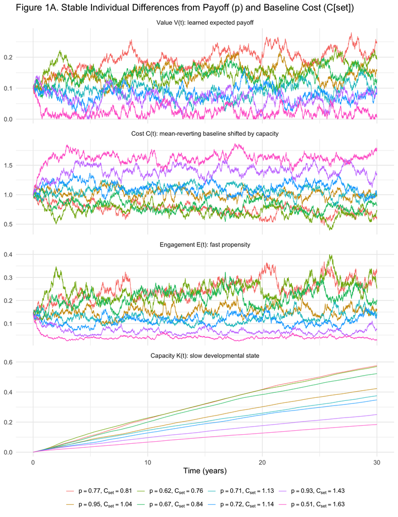

```r
# ============================================================
# Figure 1A: Stable individual differences from (i) payoff and (ii) baseline cost
#   - Children differ in:
#       p_reward  : how often EF pays off (environment)
#       C_set     : baseline perceived effort cost (trait/context)
#   - Plot four quantities to make the mechanism transparent:
#       V(t): learned value of engaging
#       C(t): subjective cost (mean-reverting to C_set, shifted down by K)
#       K(t): capacity (slow developmental state)
#       E(t): momentary engagement propensity (fast behavior)
# ============================================================

set.seed(123)
N_agents <- 8

p_mu <- 0.70
p_sd <- 0.15
Cset_mu <- 1.0
Cset_sd <- 0.35

child_pars <- tibble(
  child = paste0("child_", 1:N_agents),
  p_reward_child = pmin(pmax(rnorm(N_agents, mean = p_mu, sd = p_sd), 0.10), 0.95),
  C_set_child    = pmax(rnorm(N_agents, mean = Cset_mu, sd = Cset_sd), 0)
) %>%
  mutate(
    # ordering key: higher p and lower C_set should appear earlier in the legend
    ord = p_reward_child - C_set_child,

    # plotmath label for legend (renders C_{set})
    label = sprintf("p==%.2f*','~C[set]==%.2f", p_reward_child, C_set_child)
  ) %>%
  arrange(desc(ord)) %>%
  mutate(
    child = factor(child, levels = child),
    label = factor(label, levels = label)  # lock legend order
  )

years_total_figure <- 30
H_weeks_figure     <- years_total_figure * weeks_per_year
T_total_figure     <- round(H_weeks_figure / dt) + 1

sims_A <- lapply(1:N_agents, function(i){
  args_i <- modifyList(default_pars, list(
    T        = T_total_figure,
    p_reward = child_pars$p_reward_child[i],
    C_set    = child_pars$C_set_child[i],
    seed     = 456 + i
  ))

  do.call(simulate_ef_sde, args_i) %>%
    mutate(child = child_pars$child[i]) %>%
    left_join(child_pars, by = "child")
})

df_A <- bind_rows(sims_A)

df_A_long <- df_A %>%
  select(year, child, label, V, C, E, K) %>%
  pivot_longer(cols = c(V, C, E, K), names_to = "var", values_to = "value") %>%
  mutate(
    var = factor(var, levels = c("V", "C", "E", "K")),
    var_lab = recode(var,
      V = "Value V(t): learned expected payoff",
      C = "Cost C(t): mean-reverting baseline shifted by capacity",
      E = "Engagement E(t): fast propensity",
      K = "Capacity K(t): slow developmental state"
    ),
    var_lab = factor(var_lab, levels = var_lab[match(levels(var), var)])
  )

ggplot(df_A_long, aes(year, value, color = label, group = child)) +
  geom_line(alpha = 0.95, linewidth = 0.4) +
  facet_wrap(~ var_lab, ncol = 1, scales = "free_y") +
  theme_minimal(base_size = 14) +
  labs(
    title = "Figure 1A. Stable Individual Differences from Payoff (p) and Baseline Cost (C[set])",
    x = "Time (years)",
    y = NULL,
    color = NULL
  ) +
  scale_color_discrete(labels = function(x) parse(text = x)) +
  theme(legend.position = "bottom")
```

#### What the panels show:

**Mechanism:** $p_{\text{reward}}$ influences the value-of-control pathway $(V)$, while $C_{\text{set}}$ sets the baseline difficulty of engaging. Together they shape engagement $E(t)$, which drives practice-based growth in $K(t)$; rising $K(t)$ then reduces subjective costs $C(t)$, stabilizing individual differences over development.

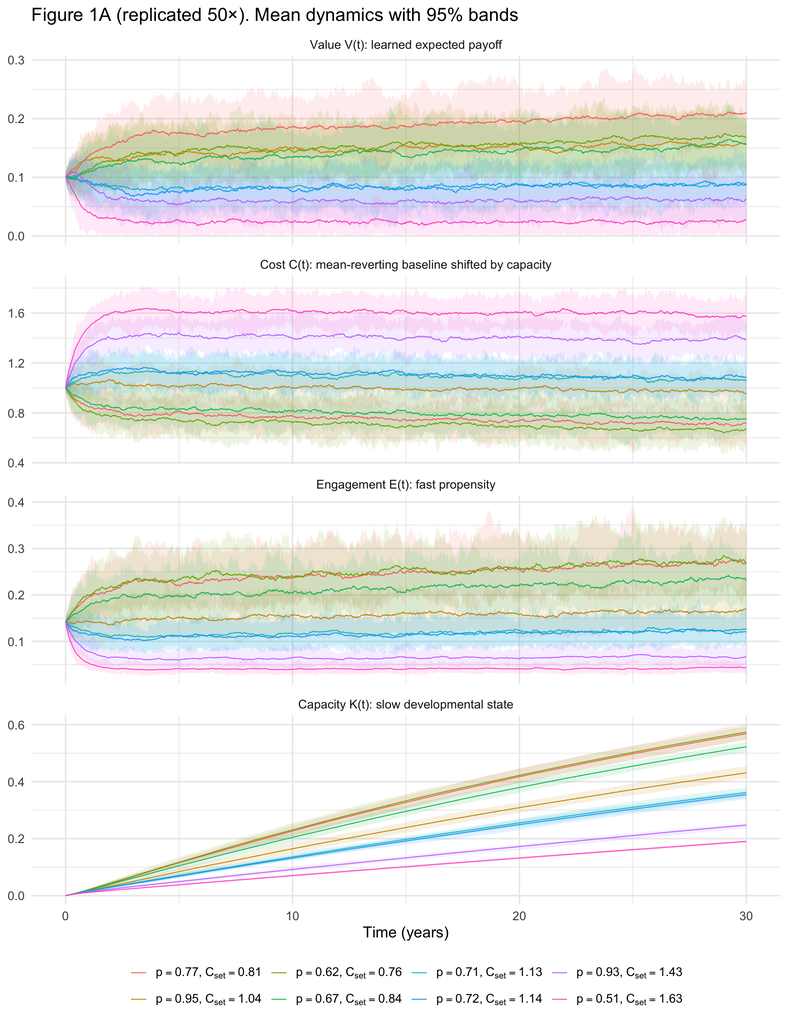

```r
# ----------------------------
# Settings
# ----------------------------
R <- 50                 # >= 30 replicates
seed_base <- 10000
years_total_figure <- 30

H_weeks_figure <- years_total_figure * weeks_per_year
T_total_figure <- round(H_weeks_figure / dt) + 1

# Downsample factor to reduce RAM/time:
# dt=0.1 week => 10 steps per week. If thin_k=10, you keep weekly points.
thin_k <- 10

# ----------------------------
# Parallel plan
#   - multisession works on Windows/macOS/Linux
#   - set workers based on your machine
# ----------------------------
plan(multisession, workers = max(1, parallel::detectCores() - 1))

# ----------------------------
# Build run grid (child × replicate)
# Assumes you already have child_pars with columns:
#   child, p_reward_child, C_set_child, label
# ----------------------------
run_grid <- tidyr::crossing(
  child_idx = seq_len(nrow(child_pars)),
  rep = seq_len(R)
) %>%
  dplyr::mutate(
    child   = child_pars$child[child_idx],
    label   = child_pars$label[child_idx],
    p_reward = child_pars$p_reward_child[child_idx],
    C_set    = child_pars$C_set_child[child_idx],
    seed     = seed_base + 1000 * child_idx + rep
  )

# ----------------------------
# Parallel simulation runner
# ----------------------------
simulate_one <- function(T, dt, p_reward, C_set, seed, child, label, rep, thin_k){
  args_i <- modifyList(default_pars, list(
    T        = T,
    p_reward = p_reward,
    C_set    = C_set,
    seed     = seed
  ))

  df <- do.call(simulate_ef_sde, args_i) %>%
    dplyr::mutate(child = child, label = label, rep = rep)

  # Optional thinning (strongly recommended)
  if (!is.null(thin_k) && thin_k > 1) {
    df <- df[seq(1, nrow(df), by = thin_k), ]
  }
  df
}

df_rep <- future_pmap_dfr(
  .l = list(
    T       = run_grid$T_total_figure %||% T_total_figure, # fallback if column absent
    dt      = dt,
    p_reward= run_grid$p_reward,
    C_set   = run_grid$C_set,
    seed    = run_grid$seed,
    child   = run_grid$child,
    label   = run_grid$label,
    rep     = run_grid$rep,
    thin_k  = thin_k
  ),
  .f = simulate_one,
  .options = furrr_options(seed = TRUE)
)
# ----------------------------
# Summarize mean + 95% interval over replicates
# ----------------------------
df_sum <- df_rep %>%
  dplyr::select(year, label, child, V, C, E, K) %>%
  tidyr::pivot_longer(cols = c(V, C, E, K), names_to = "var", values_to = "value") %>%
  dplyr::group_by(label, child, year, var) %>%
  dplyr::summarize(
    mean = mean(value, na.rm = TRUE),
    lo   = stats::quantile(value, 0.025, na.rm = TRUE),
    hi   = stats::quantile(value, 0.975, na.rm = TRUE),
    .groups = "drop"
  ) %>%
  dplyr::mutate(
    var = factor(var, levels = c("V", "C", "E", "K")),
    var_lab = dplyr::recode(var,
      V = "Value V(t): learned expected payoff",
      C = "Cost C(t): mean-reverting baseline shifted by capacity",
      E = "Engagement E(t): fast propensity",
      K = "Capacity K(t): slow developmental state"
    ),
    var_lab = factor(var_lab, levels = var_lab[match(levels(var), var)])
  )

# ----------------------------
# Plot (mean line + 95% band)
# ----------------------------
ggplot(df_sum, aes(year, mean, color = label, group = label)) +
  geom_ribbon(aes(ymin = lo, ymax = hi, fill = label),
              alpha = 0.12, color = NA, show.legend = FALSE) +
  geom_line(linewidth = 0.4) +
  facet_wrap(~ var_lab, ncol = 1, scales = "free_y") +
  theme_minimal(base_size = 14) +
  labs(
    title = sprintf("Figure 1A (replicated %d×). Mean dynamics with 95%% bands", R),
    x = "Time (years)",
    y = NULL,
    color = NULL
  ) +
  scale_color_discrete(labels = function(x) parse(text = x)) +
  theme(legend.position = "bottom")
```